# Data analysis: Techno-optimistic scientists take fewer climate actions

Fabian Dablander

26 August, 2026

# Setup

This document runs the statistical analyses reported in the paper Dablander, F., Cologna, V., Sachisthal, M.S.M., & Haslbeck, J.M.B. (2026). Techno-optimistic scientists take fewer climate actions.

```r
library(brms)
library(knitr)
library(dplyr)
library(scales)
library(ggplot2)
library(tidyverse)
library(gridExtra)
library(doParallel)
library(kableExtra)
library(RColorBrewer)
library(marginaleffects)
options(brms.backend = 'cmdstanr')
source('helpers.R')
```

# Data preparation

We load the data and create variables and categorizations that are useful for the subsequent analyses.

```r
dat_final <- readRDS('data/DataS3_Final.RDS') %>%
  mutate(
    engaged_protest = as.numeric(BehLegal == 2),
    engaged_advocacy = as.numeric(Beh_EngPub == 2),
    research_fact = factor(
      Research_std,
      labels = c("Not at all", "Very little", "A moderate amount", "Quite a bit", "A great deal")
    )
  )

dat_num <- readRDS('data/DataS1_Anonymized.RDS') %>%
  mutate(
    # Natural science as reference category
    humanities = as.numeric(
      Field == 1 | open_field == "Humanities (e.g., History, Languages, Law)"
    ),
    social_science = as.numeric(
      Field == 2 | open_field == "Social and behavioral sciences (e.g., Economics, Sociology, Psychology)"
    ),
    natural_science = as.numeric(
      Field == 3 | open_field == 'Natural sciences (e.g., Biology, Chemistry, Earth sciences)'
    ),
    formal_science = as.numeric(
      Field == 4 | open_field == "Formal sciences (e.g., Computer science, Logic, Mathematics)"
    ),
    applied_science = as.numeric(
      Field == 5 | open_field == "Professions and applied sciences (e.g., Agriculture, Engineering)"
    ),
    medical_science = as.numeric(open_field == "Medical sciences"),
    other_science = as.numeric(open_field == "Other, please specify:"),

    fieldname = case_when(
      humanities == 1 ~ 'Humanities',
      social_science == 1 ~ 'Social and behavioral sciences',
      formal_science == 1 ~ 'Formal sciences',
      applied_science == 1 ~ 'Professions and applied sciences',
      medical_science == 1 ~ 'Medical sciences',
      other_science == 1 ~ 'Other',
      natural_science == 1 ~ 'Natural sciences',
      TRUE ~ NA_character_
      # TRUE ~ 'Natural sciences'
    ),

    position_name = case_when(
      Position == 1 ~ 'PhD candidate',
      Position == 2 ~ 'Postdoc',
      Position == 3 ~ 'Assisstant professor',
      Position == 4 ~ 'Associate professor',
      Position == 5 ~ 'Full professor',
      is.na(Position) ~ NA_character_,
      TRUE ~ 'Other'
    ),

    position_name_full = case_when(
      Position == 1 ~ 'PhD candidate',
      Position == 2 ~ 'Postdoc',
      Position == 3 ~ 'Assisstant professor',
      Position == 4 ~ 'Associate professor',
      Position == 5 ~ 'Full professor',
      Position == 7 ~ 'Scientist or researcher in industry',
      Position == 8 ~ 'Scientist or researcher at a public research institute',
      Position == 9 ~ 'Scientist or researcher at a non-profit organization',
      Position == 10 ~ 'Other',
      TRUE ~ NA_character_
    ),

    reduced_car = as.numeric(Beh_incNotApp_1 == 2),
    electric_vehicle = as.numeric(Beh_incNotApp_2 == 2),
    energy_home = as.numeric(Beh_incNotApp_3 == 2),
    fewer_children = as.numeric(Beh_incNotApp_4 == 2),
    talk_climate = as.numeric(Beh_incNotApp_5 == 2),
    donate_money = as.numeric(Beh_incNotApp_6 == 2),
    veggie_diet = as.numeric(Beh_incNotApp_7 == 2),
    reduced_flying = as.numeric(Beh_incNotApp_8 == 2),

    signed_petitions = as.numeric(Beh_others_1 == 2),
    advocated_change = as.numeric(Beh_others_2 == 2),
    engaged_policymakers = as.numeric(Beh_others_3 == 2),
    wrote_letters = as.numeric(Beh_others_4 == 2),
    engaged_disobedience = as.numeric(Beh_others_7 == 2),
    engaged_protest = as.numeric(BehLegal == 2),
    engaged_advocacy = as.numeric(Beh_EngPub == 2)
  )

dat_final$position <- factor(
  dat_num$position_name,
  levels = c(
    'Full professor', 'Associate professor', 'Assisstant professor',
    'Postdoc', 'PhD candidate', 'Other'
  )
)

dat_final$political = factor(
  dat_final$Political_std, labels = c('1 (Left)', '2', '3', '4', '5', '6', '7 (Right)')
)

dat_final$fieldname <- dat_num$fieldname
dat_final$field <- factor(
  dat_num$fieldname,
  levels = c(
    'Natural sciences', 'Social and behavioral sciences', 'Medical sciences',
    'Formal sciences', 'Humanities', 'Professions and applied sciences', 'Other'
  )
)

dat_final <- dat_final %>%
  mutate(
    techno_optimism = factor(
      ToC1_2_std,
      labels = c('Strongly disagree', 'Disagree', 'Neutral', 'Agree', 'Strongly agree')
    ),

    techno_optimism_trin = factor(
      ifelse(
        techno_optimism %in% c('Strongly disagree', 'Disagree'), 'Disagree',
        ifelse(techno_optimism == 'Neutral', 'Neutral', 'Agree')
      ),
      levels = c('Disagree', 'Neutral', 'Agree')
    ),

    informed = factor(
      Informed_std, labels = c('Not at all', 'Very little', 'A moderate amount', 'Quite a bit', 'A great deal')
    )
)

# There are 87 missing responses for continent, code them as 'not specified'
dat_final$continent <- ifelse(is.na(dat_num$Continent), 'not specified', dat_num$Continent)

dat_climate <- dat_final %>%
  mutate(
    climate_researcher = as.numeric(research_fact == 'A great deal')
  ) %>%
  filter(research_fact %in% c('Not at all', 'A great deal'))

behaviors <- list(
  # Civic behaviors
  'talk_climate' = 'Talked about climate with others',
  'donate_money' = 'Donated to climate organizations',
  'signed_petitions' = 'Signed petitions',
  'advocated_change' = 'Advocated change within institution',
  'engaged_policymakers' = 'Engaged with politicians',
  'engaged_disobedience' = 'Engaged in civil disobedience',
  'engaged_protest' = 'Engaged in protest',
  'engaged_advocacy' = 'Engaged in advocacy',
  'wrote_letters' = 'Wrote letters to politicians',


  # Professional behaviors (analysed separately below)
  'shifted_research' = 'Shifted research to climate change',
  'included_teaching' = 'Included climate change in teaching',

  # Lifestyle behaviors
  'reduced_flying' = 'Reduced flying',
  'reduced_car' = 'Reduced car usage',
  'electric_vehicle' = 'Switched to electric vehicle',
  'energy_home' = 'Switched to renewable energy at home',
  'veggie_diet' = 'Follows a mostly vegetarian or vegan diet',
  'fewer_children' = 'Decided to have fewer or no children'
)

behavior_map <- list(
  'Civic action' = unlist(behaviors[seq(9)]),
  'Lifestyle change' = unlist(behaviors[seq(12, 17)])
)
behavior_names_map <- unlist(behaviors)
```

We lose 21 cases (0.2%) that have NA in either `Position` or `Field`.

```r
nrow(dat_final) - nrow(drop_na(dat_final, position, field))
```

```
## [1] 21
```

```r
dat_final <- drop_na(dat_final, position, field)
```

## Figure 2: Techno-optimism across research, scientific field, political orientation

We show the model-implied percentages of the techno-optimism variable, as well as the model-implied percentage of techno-optimistic scientists across research related to climate change, scientific field, and political orientation.

```r
fill_col <- 'gray56'

form <- paste0(
  'techno_optimism ~ ',
  'research_fact + informed + Age_std + political + position + field + ',
  'continent + is_tenured + is_female + is_gender_other'
)

filename <- 'models/techno_optimism.RDS'

dat_final$techno_optimism <- as.ordered(dat_final$techno_optimism)
fit <- run_model(
  form, filename, dat_final, use_model = NULL,
  cores = 4, chains = 4, family = cumulative('probit'), iter = 2000, warmup = 500
)


if (!file.exists('results/techno_pred.RDS')) {
  dat_techno_pred <- avg_predictions(fit)
  saveRDS(dat_techno_pred, 'results/techno_pred.RDS')
} else {
  dat_techno_pred <- data.frame(readRDS('results/techno_pred.RDS'))
}

if (!file.exists('results/research_pred.RDS')) {
  dat_research_pred <- avg_predictions(fit, variable = 'research_fact')
  saveRDS(dat_research_pred, 'results/research_pred.RDS')
} else {
  dat_research_pred <- readRDS('results/research_pred.RDS')
}

df_draws <- get_draws(dat_research_pred)

df_research_combined <- df_draws %>%
  filter(group %in% c('Strongly agree', 'Agree')) %>%
  # For each draw and political orientation
  group_by(drawid, research_fact) %>%
  # Sum the predicted probabilities across Strongly agree and Agree
  summarise(draw = sum(draw), .groups = "drop") %>%
  group_by(research_fact) %>%
  summarise(
    estimate = mean(draw),
    ci_lo = quantile(draw, 0.025),
    ci_hi = quantile(draw, 0.975),
    .groups = 'drop'
  )

if (!file.exists('results/political_pred.RDS')) {
  dat_political_pred <- avg_predictions(fit, variable = 'political')
  saveRDS(dat_political_pred, 'results/political_pred.RDS')
} else {
  dat_political_pred <- readRDS('results/political_pred.RDS')
}

df_draws <- get_draws(dat_political_pred)

df_political_combined <- df_draws %>%
  filter(group %in% c('Strongly agree', 'Agree')) %>%
  # For each draw and political orientation
  group_by(drawid, political) %>%
  # Sum the predicted probabilities across Strongly agree and Agree
  summarise(draw = sum(draw), .groups = "drop") %>%
  group_by(political) %>%
  summarise(
    estimate = mean(draw),
    ci_lo = quantile(draw, 0.025),
    ci_hi = quantile(draw, 0.975),
    .groups = 'drop'
  )

if (!file.exists('results/field_pred.RDS')) {
  dat_field_pred <- avg_predictions(fit, variable = 'field')
  saveRDS(dat_field_pred, 'results/field_pred.RDS')
} else {
  dat_field_pred <- readRDS('results/field_pred.RDS')
}

df_draws <- get_draws(dat_field_pred)

df_field_combined <- df_draws %>%
  filter(group %in% c('Strongly agree', 'Agree')) %>%
  # For each draw and scientific field
  group_by(drawid, field) %>%
  # Sum the predicted probabilities across Strongly agree and Agree
  summarise(draw = sum(draw), .groups = "drop") %>%
  group_by(field) %>%
  summarise(
    estimate = mean(draw),
    ci_lo = quantile(draw, 0.025),
    ci_hi = quantile(draw, 0.975),
    .groups = 'drop'
  ) %>%
  mutate(
    field = as.character(field),
    field = case_when(
      field == 'Social and behavioral sciences' ~ 'Social & \n behavioral \n sciences',
      field == 'Professions and applied sciences' ~ 'Professions & \n applied \n sciences',
      field == 'Formal sciences' ~ 'Formal \n sciences',
      field == 'Natural sciences' ~ 'Natural \n sciences',
      field == 'Medical sciences' ~ 'Medical \n sciences',
      TRUE ~ field
    ),
    field = fct_reorder(field, estimate)
  )

ptechno <- ggplot(dat_techno_pred, aes(x = group, y = estimate)) +
  geom_bar(stat = 'identity', fill = fill_col, color = 'black') +
  geom_point(
    size = 3, show.legend = FALSE, color = 'black'
  ) +
  geom_errorbar(
    aes(ymin = conf.low, ymax = conf.high),
    width = 0.30, linewidth = 1, show.legend = FALSE, color = 'black'
  ) +
  theme_minimal() +
  ylab('Percentage of scientists') +
  xlab('') +
  ggtitle('Techno-optimism') +
  scale_y_continuous(
    breaks = seq(0, 0.4, 0.10), limits = c(0, 0.40), labels = label_percent(scale = 100)
  ) +
  theme(
    plot.title = element_text(hjust = 0.50, size = 18),
    axis.text.x = element_text(size = 12),
    axis.text.y = element_text(size = 12),
    axis.title.y = element_text(size = 14),
    panel.grid.minor.y = element_blank(),
    panel.grid.major.y = element_blank(),
    panel.grid.major.x = element_blank()
  )

presearch <- ggplot(df_research_combined, aes(x = research_fact, y = estimate)) +
  geom_bar(stat = 'identity', fill = fill_col, color = 'black') +
  geom_point(
    size = 3, show.legend = FALSE, color = 'black'
  ) +
  geom_errorbar(
    aes(ymin = ci_lo, ymax = ci_hi),
    width = 0.30, linewidth = 1, show.legend = FALSE, color = 'black'
  ) +
  theme_minimal() +
  ylab('') +
  xlab('') +
  ggtitle('Research related to climate change') +
  ylab('Percentage techno-optimistics') +
  scale_y_continuous(
    breaks = seq(0, 0.4, 0.10), limits = c(0, 0.40), labels = label_percent(scale = 100)
  ) +
  theme(
    plot.title = element_text(hjust = 0.50, size = 18),
    axis.text.x = element_text(size = 12),
    axis.text.y = element_text(size = 12),
    axis.title.y = element_text(size = 14),
    panel.grid.minor.y = element_blank(),
    panel.grid.major.y = element_blank(),
    panel.grid.major.x = element_blank()
  )

pfield <- ggplot(df_field_combined, aes(x = field, y = estimate)) +
  geom_bar(stat = 'identity', fill = fill_col, color = 'black') +
  geom_point(
    size = 3, show.legend = FALSE, color = 'black'
  ) +
  geom_errorbar(
    aes(ymin = ci_lo, ymax = ci_hi),
    width = 0.30, linewidth = 1, show.legend = FALSE, color = 'black'
  ) +
  theme_minimal() +
  ylab('Percentage techno-optimistics') +
  xlab('') +
  ggtitle('Scientific field') +
  scale_y_continuous(
    breaks = seq(0, 0.4, 0.10), limits = c(0, 0.40), labels = label_percent(scale = 100)
  ) +
  theme(
    plot.title = element_text(hjust = 0.50, size = 18),
    axis.text.x = element_text(size = 12),
    axis.text.y = element_text(size = 12),
    axis.title.y = element_text(size = 14),
    panel.grid.minor.y = element_blank(),
    panel.grid.major.y = element_blank(),
    panel.grid.major.x = element_blank()
  )

ppolitical <- ggplot(df_political_combined, aes(x = political, y = estimate)) +
  geom_bar(stat = 'identity', fill = fill_col, color = 'black') +
  geom_point(
    size = 3, show.legend = FALSE, color = 'black'
  ) +
  geom_errorbar(
    aes(ymin = ci_lo, ymax = ci_hi),
    width = 0.30, linewidth = 1, show.legend = FALSE, color = 'black'
  ) +
  theme_minimal() +
  ylab('') +
  xlab('') +
  ggtitle('Political orientation') +
  scale_y_continuous(
    breaks = seq(0, 0.7, 0.10), limits = c(0, 0.70), labels = label_percent(scale = 100)
  ) +
  theme(
    plot.title = element_text(hjust = 0.50, size = 18),
    axis.text.x = element_text(size = 12),
    axis.text.y = element_text(size = 12),
    axis.title.y = element_text(size = 14),
    panel.grid.minor.y = element_blank(),
    panel.grid.major.y = element_blank(),
    panel.grid.major.x = element_blank()
  )

pdf('figures/Figure2.pdf', width = 14, height = 10)
grid.arrange(
  ptechno, presearch, pfield, ppolitical
)
dev.off()
```

## Figure 3: Techno-optimism and climate action

We show the model-implied percentages of engagement in civic action and lifestyle changes by techno-optimistic and non-techno-optimistic scientists, adjusting for potential confounders.

```r
all_models <- run_all_models(
  dat_final, predictor = 'techno_optimism',
  filename_ext = '', force = FALSE
)

df_effects <- estimate_effects(
  all_models, filename = 'results/effects.csv',
  predictor = 'techno_optimism',
  force = FALSE
)

df_effects$behavior <- unlist(behaviors[df_effects$behavior])
df_effects <- order_effects(df_effects) %>% filter(class == 'adjusted')
```

We estimate the average (adjusted) difference between techno-optimistic and non-techno-optimistic scientists for civic actions (9%) and lifestyle changes (10%).

```r
df_effects %>%
  group_by(class, category) %>%
  summarize(
    mean_estimate = mean(estimate[combined == 'Disagree'] - estimate[combined == 'Agree'])
  )
```

```
## # A tibble: 2 × 3
## # Groups:   class [1]
##   class    category         mean_estimate
##   <chr>    <fct>                    <dbl>
## 1 adjusted Civic action            0.0880
## 2 adjusted Lifestyle change        0.0966
```

```r
cols <- c('#c44e52', '#4c72b0')
p <- ggplot(
  df_effects %>% filter(class == 'adjusted'),
  aes(x = behavior, y = estimate, group = combined, color = combined)) +
  geom_bar(
    stat = 'identity', position = position_dodge(width = 0.8),
    width = 0.70, aes(fill = combined)
  ) +
  geom_point(
    aes(x = behavior, y = estimate), position = position_dodge(width = 0.80),
    size = 2, show.legend = FALSE, color = 'black'
  ) +
  geom_errorbar(
    aes(ymin = ci_lo, ymax = ci_hi), position = position_dodge(width = 0.80),
    width = 0.40, linewidth = 1, show.legend = FALSE, color = 'black'
  ) +
  geom_point(
    aes(x = behavior, y = estimate), position = position_dodge(width = 0.80),
    size = 1, show.legend = FALSE
  ) +
  geom_errorbar(
    aes(ymin = ci_lo, ymax = ci_hi), position = position_dodge(width = 0.80),
    width = 0.30, linewidth = 0.30,
    show.legend = FALSE
  ) +
  theme_minimal() +
  coord_flip() +
  xlab('') +
  ylab('Percent reported engaging') +
  scale_x_discrete(guide = guide_axis(angle = 0)) +
  scale_color_manual(values = cols) +
  scale_fill_manual(
    values = cols,
    labels = c('Agree with techno-optimism (n = 2,531)', 'Disagree with techno-optimism (n = 4,006)')
  ) +
  scale_y_continuous(
    labels = label_percent(scale = 100), limits = c(0, 0.85), breaks = seq(0, 1, 0.10)
  ) +
  ggtitle('Climate actions across techno-optimism beliefs') +
  theme(
    legend.position = 'top',
    legend.title = element_blank(),
    panel.grid.minor = element_blank(),
    panel.grid.major.y = element_blank(),
    axis.title.x = element_text(size = 12),
    axis.title.y = element_text(size = 12),
    axis.text.x = element_text(size = 10),
    axis.text.y = element_text(size = 10),
    plot.title = element_text(hjust = .5, size = 14),
    strip.text.x = element_text(size = 9, face = 'bold')
  ) + guides(fill = guide_legend(reverse = TRUE, ncol = 1), color = FALSE)

p
```

[figure not shown]

```r
ggsave('figures/Figure3.pdf', p, width = 8, height = 10)
```

Here are the (adjusted) differences for the two professional behaviors.

```r
teaching_form <- as.formula(paste0(
  'included_teaching ~ ',
  'techno_optimism + informed + research_fact + Age_std + ',
  'political + position + field + continent + is_tenured + ',
  'is_female + is_gender_other'
))

research_form <- as.formula(paste0(
  'shifted_research ~ ',
  'techno_optimism + informed + research_fact + Age_std + ',
  'political + position + field + continent + is_tenured + ',
  'is_female + is_gender_other'
))

fit_teaching <- run_model(teaching_form, 'models/adjusted_included_teaching.RDS', use_model = NULL)
fit_research <- run_model(research_form, 'models/adjusted_shifted_research.RDS', use_model = NULL)

get_effects_proper(fit_teaching, 'included_teaching')
```

```
## # A tibble: 2 × 5
##   combined estimate ci_lo ci_hi behavior
##   <chr>       <dbl> <dbl> <dbl> <chr>
## 1 Agree       0.468 0.450 0.487 included_teaching
## 2 Disagree    0.517 0.503 0.530 included_teaching
```

```r
get_effects_proper(fit_research, 'shifted_research')
```

```
## # A tibble: 2 × 5
##   combined estimate ci_lo ci_hi behavior
##   <chr>       <dbl> <dbl> <dbl> <chr>
## 1 Agree       0.489 0.473 0.503 shifted_research
## 2 Disagree    0.500 0.489 0.511 shifted_research
```

# Supplementary analyses

## Table S1 & S2: Descriptive statistics

Here we show descriptive statistics of a number of background variables.

```r
age_labels <- c(
  'Under 18', '18 - 24 years', '25-34 years',
  '35-44 years', '45-54 years', '55-64 years', '65+ years'
)
gender_labels <- c('Male', 'Female', 'Non-binary', 'Prefer to self-describe', 'Prefer not to say')
field_labels <- c(
  'Social and behavioral sciences', 'Natural sciences', 'Medical sciences',
  'Professions and applied sciences', 'Formal sciences', 'Humanities', 'Other'
)
position_labels <- c(
  'PhD candidate', 'Postdoc', 'Assisstant professor',
  'Associate professor', 'Full professor',
  'Scientist or researcher in industry',
  'Scientist or researcher at a public research institute',
  'Scientist or researcher at a non-profit organization',
  'Other'
)
political_labels <- c('1', '2', '3', '4', '5', '6', '7')
tenured_labels <- c('No', 'Yes')
climate_labels <- c('Not at all', 'Very little', 'A moderate amount', 'Quite a bit', 'A great deal')
techno_labels <- c('Strongly disagree', 'Disagree', 'Neutral', 'Agree', 'Strongly agree')
continent_labels <- c('Europe', 'North America', 'South America', 'Asia', 'Africa', 'Oceania')
informed_labels <- c('Not at all', 'Very little', 'A moderate amount', 'Quite a bit', 'A great deal')

dat_descr <- dat_num %>%
  mutate(
    Age = factor(Age, labels = age_labels),
    Gender = factor(Gender, labels = gender_labels),
    fieldname = factor(fieldname, levels = field_labels),
    Position = factor(position_name_full, labels = position_labels),
    Political = factor(Political, labels = political_labels),
    Techno = factor(ToC1_2, labels = techno_labels),
    Research = factor(Research, labels = informed_labels),
    Informed = factor(Informed, labels = informed_labels)
  )

dat_age <- dat_descr %>%
  group_by(Age) %>%
  summarize(n_age = n()) %>%
  mutate(prop_age = 100 * round(n_age / sum(n_age), 2)) %>%
  mutate(final_age = paste0(n_age, ' (', prop_age, '%)')) %>%
  select(Age, final_age)

dat_gender <- dat_descr %>%
  group_by(Gender) %>%
  summarize(n_gender = n()) %>%
  mutate(prop_gender = 100 * round(n_gender / sum(n_gender), 2)) %>%
  mutate(final_gender = paste0(n_gender, ' (', prop_gender, '%)')) %>%
  select(Gender, final_gender)

dat_cont <- dat_descr %>%
  group_by(Continent) %>%
  summarize(n_cont = n()) %>%
  mutate(prop_cont = 100 * round(n_cont / sum(n_cont), 2)) %>%
  mutate(final_cont = paste0(n_cont, ' (', prop_cont, '%)')) %>%
  select(Continent, final_cont)

dat_field <- dat_descr %>%
  select(-Field) %>%
  rename(Field = fieldname) %>%
  group_by(Field) %>%
  summarize(n_field = n()) %>%
  mutate(prop_field = 100 * round(n_field / sum(n_field), 2)) %>%
  mutate(final_field = paste0(n_field, ' (', prop_field, '%)')) %>%
  select(Field, final_field)

dat_pos <- dat_descr %>%
  group_by(Position) %>%
  summarize(n_pos = n()) %>%
  mutate(prop_pos = 100 * round(n_pos / sum(n_pos), 2)) %>%
  mutate(final_pos = paste0(n_pos, ' (', prop_pos, '%)')) %>%
  select(Position, final_pos)

dat_techno <- dat_descr %>%
  group_by(Techno) %>%
  summarize(n = n()) %>%
  mutate(prop = 100 * round(n / sum(n), 2)) %>%
  mutate(final_techno = paste0(n, ' (', prop, '%)')) %>%
  select(Techno, final_techno)

dat_pol <- dat_descr %>%
  group_by(Political) %>%
  summarize(n_pol = n()) %>%
  mutate(prop_pol = 100 * round(n_pol / sum(n_pol), 2)) %>%
  mutate(final_pol = paste0(n_pol, ' (', prop_pol, '%)')) %>%
  select(Political, final_pol)

dat_inf <- dat_descr %>%
  group_by(Informed) %>%
  summarize(n_inf = n()) %>%
  mutate(prop_inf = 100 * round(n_inf / sum(n_inf), 2)) %>%
  mutate(final_inf = paste0(n_inf, ' (', prop_inf, '%)')) %>%
  select(Informed, final_inf)

dat_res <- dat_descr %>%
  group_by(Research) %>%
  summarize(n = n()) %>%
  mutate(prop = 100 * round(n / sum(n), 2)) %>%
  mutate(final_res = paste0(n, ' (', prop, '%)')) %>%
  select(Research, final_res)

prep <- function(df, value) {
  varname <- colnames(df)[1]
  df$Variable <- varname
  colnames(df) <- c('Variable', 'Frequency', 'Variablename')
  df %>%
    select(Variablename, Variable, Frequency)
}

# Background / socio-demographics
df_ses <- bind_rows(
  prep(dat_age, 'final_age'),
  prep(dat_gender, 'final_gender'),
  prep(dat_cont, 'final_cont'),
  prep(dat_field, 'final_field'),
  prep(dat_pos, 'final_pos')
)

df_info <- bind_rows(
  prep(dat_techno, 'final_techno'),
  prep(dat_pol, 'final_pol'),
  prep(dat_inf, 'final_inf'),
  prep(dat_res, 'final_res')
)

kable_ses <- kable(df_ses, booktabs = TRUE)
print(kable_ses)
```

```
##
##
## |Variablename |Variable                                               |Frequency  |
## |:------------|:------------------------------------------------------|:----------|
## |Age          |Under 18                                               |2 (0%)     |
## |Age          |18 - 24 years                                          |14 (0%)    |
## |Age          |25-34 years                                            |1674 (18%) |
## |Age          |35-44 years                                            |3197 (35%) |
## |Age          |45-54 years                                            |2087 (23%) |
## |Age          |55-64 years                                            |1368 (15%) |
## |Age          |65+ years                                              |843 (9%)   |
## |Age          |NA                                                     |35 (0%)    |
## |Gender       |Male                                                   |5659 (61%) |
## |Gender       |Female                                                 |3274 (36%) |
## |Gender       |Non-binary                                             |56 (1%)    |
## |Gender       |Prefer to self-describe                                |27 (0%)    |
## |Gender       |Prefer not to say                                      |184 (2%)   |
## |Gender       |NA                                                     |20 (0%)    |
## |Continent    |Africa                                                 |110 (1%)   |
## |Continent    |Asia                                                   |1031 (11%) |
## |Continent    |Europe                                                 |4703 (51%) |
## |Continent    |North America                                          |2477 (27%) |
## |Continent    |Oceania                                                |464 (5%)   |
## |Continent    |South America                                          |348 (4%)   |
## |Continent    |NA                                                     |87 (1%)    |
## |Field        |Social and behavioral sciences                         |2230 (24%) |
## |Field        |Natural sciences                                       |3937 (43%) |
## |Field        |Medical sciences                                       |816 (9%)   |
## |Field        |Professions and applied sciences                       |1583 (17%) |
## |Field        |Formal sciences                                        |288 (3%)   |
## |Field        |Humanities                                             |195 (2%)   |
## |Field        |Other                                                  |159 (2%)   |
## |Field        |NA                                                     |12 (0%)    |
## |Position     |PhD candidate                                          |1390 (15%) |
## |Position     |Postdoc                                                |1670 (18%) |
## |Position     |Assisstant professor                                   |2438 (26%) |
## |Position     |Associate professor                                    |454 (5%)   |
## |Position     |Full professor                                         |552 (6%)   |
## |Position     |Scientist or researcher in industry                    |1128 (12%) |
## |Position     |Scientist or researcher at a public research institute |242 (3%)   |
## |Position     |Scientist or researcher at a non-profit organization   |1153 (13%) |
## |Position     |Other                                                  |179 (2%)   |
## |Position     |NA                                                     |14 (0%)    |
```

```r
kable_info <- kable(df_info, booktabs = TRUE)
print(kable_info)
```

```
##
##
## |Variablename |Variable          |Frequency  |
## |:------------|:-----------------|:----------|
## |Techno       |Strongly disagree |1164 (13%) |
## |Techno       |Disagree          |2847 (31%) |
## |Techno       |Neutral           |2665 (29%) |
## |Techno       |Agree             |1971 (21%) |
## |Techno       |Strongly agree    |565 (6%)   |
## |Techno       |NA                |8 (0%)     |
## |Political    |1                 |888 (10%)  |
## |Political    |2                 |3301 (36%) |
## |Political    |3                 |2584 (28%) |
## |Political    |4                 |1581 (17%) |
## |Political    |5                 |574 (6%)   |
## |Political    |6                 |159 (2%)   |
## |Political    |7                 |43 (0%)    |
## |Political    |NA                |90 (1%)    |
## |Informed     |Not at all        |3 (0%)     |
## |Informed     |Very little       |247 (3%)   |
## |Informed     |A moderate amount |2295 (25%) |
## |Informed     |Quite a bit       |3890 (42%) |
## |Informed     |A great deal      |2783 (30%) |
## |Informed     |NA                |2 (0%)     |
## |Research     |Not at all        |2255 (24%) |
## |Research     |Very little       |1899 (21%) |
## |Research     |A moderate amount |1846 (20%) |
## |Research     |Quite a bit       |1646 (18%) |
## |Research     |A great deal      |1563 (17%) |
## |Research     |NA                |11 (0%)    |
```

## Supplementary Figure 1: Relationship with worry

We estimate the percentage of techno-optimistic scientists across levels of worry.

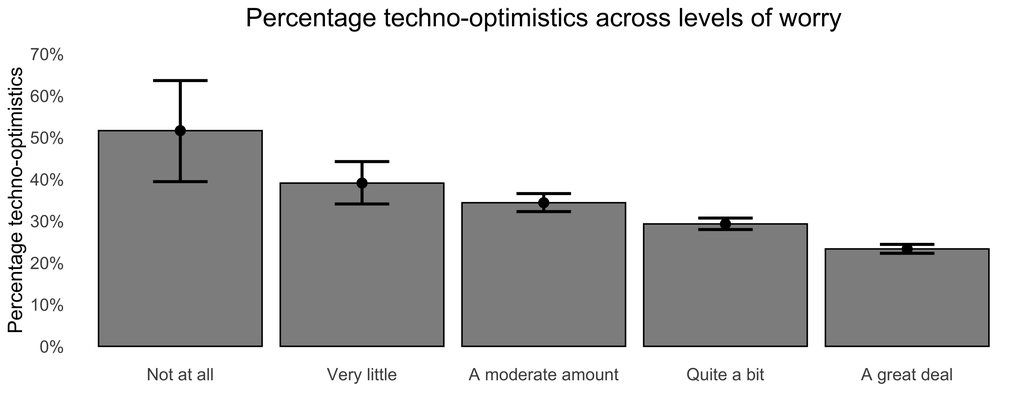

```r
dat_final$worry <- factor(
  dat_final$Worry_std,
  labels = c('Not at all', 'Very little', 'A moderate amount', 'Quite a bit', 'A great deal')
)

form <- paste0(
  'techno_optimism ~ ',
  'research_fact + informed + worry + Age_std + political + ',
  'position + field + continent + is_tenured + is_female + is_gender_other'
)

filename <- 'models/techno_optimism_worry.RDS'

fit <- run_model(
  form, filename, dat_final, use_model = NULL,
  cores = 4, chains = 4, family = cumulative('probit'), iter = 2000, warmup = 500
)

if (!file.exists('results/worry_pred.RDS')) {
  dat_worry_pred <- avg_predictions(fit, variables = 'worry')
  saveRDS(dat_worry_pred, 'results/worry_pred.RDS')
} else {
  dat_worry_pred <- readRDS('results/worry_pred.RDS')
}

df_draws <- get_draws(dat_worry_pred)

df_worry_combined <- df_draws %>%
  filter(group %in% c('Strongly agree', 'Agree')) %>%
  # For each draw and political orientation
  group_by(drawid, worry) %>%
  # Sum the predicted probabilities across Strongly agree and Agree
  summarise(draw = sum(draw), .groups = "drop") %>%
  group_by(worry) %>%
  summarise(
    estimate = mean(draw),
    ci_lo = quantile(draw, 0.025),
    ci_hi = quantile(draw, 0.975),
    .groups = 'drop'
  )

if (!file.exists('results/informed_pred.RDS')) {
  dat_informed_pred <- avg_predictions(fit, variables = 'informed')
  saveRDS(dat_informed_pred, 'results/informed_pred.RDS')
} else {
  dat_informed_pred <- readRDS('results/informed_pred.RDS')
}

df_draws <- get_draws(dat_informed_pred)

df_informed_combined <- df_draws %>%
  filter(group %in% c('Strongly agree', 'Agree')) %>%
  # For each draw and political orientation
  group_by(drawid, informed) %>%
  # Sum the predicted probabilities across Strongly agree and Agree
  summarise(draw = sum(draw), .groups = "drop") %>%
  group_by(informed) %>%
  summarise(
    estimate = mean(draw),
    ci_lo = quantile(draw, 0.025),
    ci_hi = quantile(draw, 0.975),
    .groups = 'drop'
  )

pworry <- ggplot(df_worry_combined, aes(x = worry, y = estimate)) +
  geom_bar(stat = 'identity', fill = fill_col, color = 'black') +
  geom_point(
    size = 3, show.legend = FALSE, color = 'black'
  ) +
  geom_errorbar(
    aes(ymin = ci_lo, ymax = ci_hi),
    width = 0.30, linewidth = 1, show.legend = FALSE, color = 'black'
  ) +
  theme_minimal() +
  ylab('Percentage techno-optimistics') +
  xlab('') +
  ggtitle('Percentage techno-optimistics across levels of worry') +
  scale_y_continuous(
    breaks = seq(0, 0.7, 0.10), limits = c(0, 0.70), labels = label_percent(scale = 100)
  ) +
  theme(
    plot.title = element_text(hjust = 0.50, size = 18),
    axis.text.x = element_text(size = 12),
    axis.text.y = element_text(size = 12),
    axis.title.y = element_text(size = 14),
    panel.grid.minor.y = element_blank(),
    panel.grid.major.y = element_blank(),
    panel.grid.major.x = element_blank()
  )

pworry
```

```r
ggsave('figures/FigureS1.pdf', pworry, width = 8, height = 6)
```

## Supplementary Figure 2: Relative differences

We estimate the relative decrease in climate action by techno-optimistic scientists compared to non-techno-optimistic scientists. We did not adjust for worry in the main analysis because it may well be a mediator. We adjust for worry below as a robustness check (in addition to adjusting for all the other background variables).

```r
all_models <- run_all_models(dat_final, predictor = 'techno_optimism', filename_ext = '')

df_effects_mult <- estimate_effects(
  all_models, filename = 'results/effects_relative.csv',
  predictor = 'techno_optimism',
  force = FALSE, comp = 'multiplicative'
)

all_models_worry <- run_all_models(
  dat_final, predictor = 'techno_optimism',
  filename_ext = '_worry', worry = TRUE, force = FALSE
)

df_effects_worry_mult <- estimate_effects(
  all_models_worry, filename = 'results/effects_relative_worry.csv',
  predictor = 'techno_optimism',
  force = FALSE, comp = 'multiplicative'
) %>%
  filter(class == 'adjusted') %>%
  mutate(class = 'worry')

df_effects_mult <- bind_rows(df_effects_mult, df_effects_worry_mult)

df_effects_mult$estimate <- 1 / df_effects_mult$estimate
df_effects_mult$ci_lo <- 1 / df_effects_mult$ci_lo
df_effects_mult$ci_hi <- 1 / df_effects_mult$ci_hi

df_effects_mult$behavior <- unlist(behaviors[df_effects_mult$behavior])
df_effects_mult <- order_effects(df_effects_mult, type = 'multiplicative') %>%
  mutate(
    class = factor(class, levels = c('unadjusted', 'adjusted', 'worry'))
  )
```

Additionally adjusting for worry yields an average relative decrease for techno-optimistic scientists of 24% for civic actions and 17% for lifestyle changes. The other way around, this corresponds to an average relative increase for non-techno-optimistic scientists for civic actions of 33% and lifestyle changes of 22%.

```r
df_effects_mult %>%
  group_by(class, category) %>%
  summarize(
    mean_estimate = mean(estimate)
  )
```

```
## # A tibble: 6 × 3
## # Groups:   class [3]
##   class      category         mean_estimate
##   <fct>      <fct>                    <dbl>
## 1 unadjusted Civic action             0.567
## 2 unadjusted Lifestyle change         0.706
## 3 adjusted   Civic action             0.721
## 4 adjusted   Lifestyle change         0.808
## 5 worry      Civic action             0.763
## 6 worry      Lifestyle change         0.834
```

```r
cols <- c('#D95F02', '#1B9E77')

pS2 <- ggplot(
  df_effects_mult,
  aes(x = behavior, y = estimate, color = category, shape = class, alpha = class)) +
  geom_errorbar(
    aes(ymin = ci_lo, ymax = ci_hi),
    width = 0.90, linewidth = 1,
    show.legend = TRUE,
    position = position_dodge(width = 0.80)
  ) +
  geom_point(
    aes(x = behavior, y = estimate),# position = position_dodge(width = 0.75),
    position = position_dodge(width = 0.80),
    size = 3, show.legend = TRUE
  ) +
  theme_minimal() +
  coord_flip() +
  xlab('') +
  ylab('Relative engagement') +
  ggtitle('Relative engagement in climate action for \n techno-optimistics vs non-techno-optimistics') +
  scale_x_discrete(guide = guide_axis(angle = 0)) +
  scale_color_manual(values = cols) +
  scale_shape_manual(
    values = c('triangle', 'circle', 'square'),
    labels = rev(c(
      'Adjusted for background variable + worry',
      'Adjusted for background variables',
      'Not adjusted'
    ))
  ) +
  scale_alpha_manual(
    name = NULL,
    values = c(0.25, 1, 0.50),
    labels = rev(c(
      'Adjusted for background variable + worry',
      'Adjusted for background variables',
      'Not adjusted'
    ))
  ) +
  scale_y_continuous(
    limits = c(0.20, 1.1),
    breaks = seq(0.30, 1.0, 0.1),
    labels = label_percent(scale = 100)
    # breaks = c(1, 1.2, 1.4, 1.6, 1.8, 2, 2.2, 2.6, 3, 3.8),
  ) +  # scale = 1 for proportions
  theme(
    legend.position = 'top',
    legend.title = element_blank(),
    legend.key.height = unit(0.25, "cm"),
    legend.spacing.y = unit(0, "pt"),
    panel.grid.minor = element_blank(),
    panel.grid.major.y = element_blank(),
    axis.title.x = element_text(size = 12),
    axis.title.y = element_text(size = 12),
    axis.text.x = element_text(size = 10),
    axis.text.y = element_text(size = 10),
    plot.title = element_text(hjust = .5, size = 14),
    strip.text.x = element_text(size = 9, face = 'bold'),
  ) + guides(
    shape = guide_legend(
      reverse = TRUE, ncol = 1, override.aes = list(alpha = c(0.50, 1, 0.25))
    ), color = FALSE, alpha = FALSE
  )

pS2
```

[figure not shown]

```r
ggsave('figures/FigureS2.pdf', pS2, width = 8, height = 10)
```

## Supplementary Figure 3: Average one-unit differences

We estimate the relative decrease in climate action as one increasingly agrees with techno-optimism.

```r
all_models <- run_all_models(dat_final, predictor = 'techno_optimism', filename_ext = '')
df_effects <- estimate_effects(
  all_models, filename = 'results/effects_unit.csv',
  predictor = 'techno_optimism',
  type = 'avg_comparisons'
)

df_effects$behavior <- unlist(behaviors[df_effects$behavior])
df_effects <- order_effects(df_effects, type = 'raw') %>%
  mutate(
    class = factor(class, rev(c('adjusted', 'unadjusted')))
  )
```

We estimate the average (adjusted) one-unit difference for civic actions (3.2%) and lifestyle changes (3%).

```r
df_effects %>%
  group_by(class, category) %>%
  summarize(
    mean_estimate = mean(estimate)
  )
```

```
## # A tibble: 4 × 3
## # Groups:   class [2]
##   class      category         mean_estimate
##   <fct>      <fct>                    <dbl>
## 1 unadjusted Civic action           -0.0559
## 2 unadjusted Lifestyle change       -0.0484
## 3 adjusted   Civic action           -0.0318
## 4 adjusted   Lifestyle change       -0.0298
```

```r
cols <- c('#D95F02', '#1B9E77')
pS3 <- ggplot(df_effects, aes(x = behavior, y = estimate, color = category, alpha = class)) +
  coord_flip() +
  geom_errorbar(
    aes(ymin = ci_lo, ymax = ci_hi), position = position_dodge(width = 0.75),
    width = 0.75, linewidth = 1,
    show.legend = TRUE
  ) +
  geom_point(
    aes(x = behavior, y = estimate), position = position_dodge(width = 0.75),
    size = 3, show.legend = TRUE
  ) +
  xlab('') +
  scale_y_continuous(
    limits = c(-0.12, 0.02), breaks = seq(-0.12, 0.02, 0.02),
    labels = label_percent(scale = 100)
  ) +
  ggtitle('Percentage decrease in climate action for one unit \n increase in techno-optimism') +
  ylab('Percentage decrease') +
  theme_minimal() +
  theme(legend.position = 'top') +
  theme_minimal() +
  scale_color_manual(
    values = cols
  ) +
  scale_alpha_manual(
    values = c(0.50, 1),
    labels = rev(c('Adjusted for background variables', 'Not adjusted'))
  ) +
  theme(
    legend.position = 'top',
    legend.title = element_blank(),
    panel.grid.minor = element_blank(),
    panel.grid.major.y = element_blank(),
    axis.title.x = element_text(size = 12),
    axis.title.y = element_text(size = 12),
    axis.text.x = element_text(size = 10),
    axis.text.y = element_text(size = 10),
    plot.title = element_text(hjust = .5, size = 14),
    strip.text.x = element_text(size = 9, face = 'bold')
  ) + guides(
    alpha = guide_legend(reverse = FALSE, nrow = 1),
    color = FALSE
  )

pS3
```

[figure not shown]

```r
ggsave('figures/FigureS3.pdf', pS3, width = 9, height = 10)
```

## Supplementary Figure 4: Sensitivity analysis for unobserved confounding

Here we assess how the strength of potential unobserved confounding attenuates the estimated causal effects of techno-optimism on the various climate actions. Please see the main text of the paper for details.

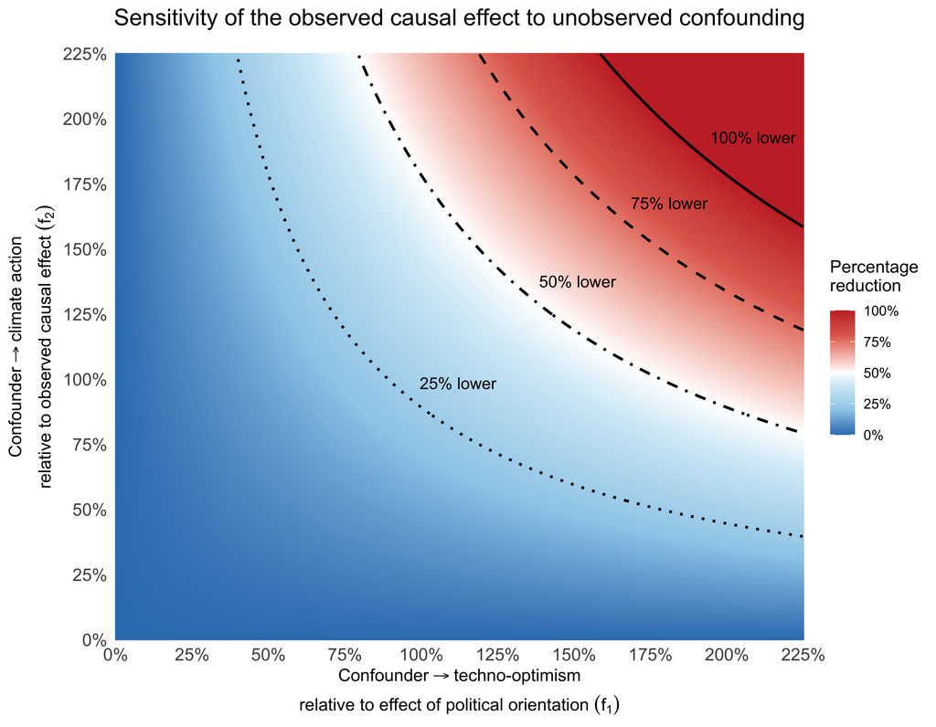

```r
all_linear_models <- run_all_models(
  dat_final, predictor = 'techno_optimism',
  filename_ext = '_linear', force = FALSE,
  sensitivity = TRUE, family = 'gaussian'
)

dat_final$techno_optimism_num <- as.numeric(dat_final$techno_optimism)

# The effect of a 1-SD increase in political orientation on techno-optimism is 0.30
fit_techno <- run_model(
  form = techno_optimism_num ~ research_fact + Age_std + Political_std + informed +
    position + field + continent + is_tenured + is_female + is_gender_other,
  dat = dat_final, family = 'gaussian', filename = 'models/techno_optimism_linear.RDS', force = FALSE
)

# Get the residual variance (posterior mode)
sd_resid_x <- mean(resid(fit_techno)[, 2])

df_effects_sens <- estimate_effects(
  all_linear_models, filename = 'results/effects_sensitivity.csv',
  predictor = 'techno_optimism',
  force = FALSE, sensitivity = TRUE
) %>%
  group_by(behavior) %>%
  summarize(tau_obs = estimate[combined == 'Disagree'] - estimate[combined == 'Agree'])

#-----------------------------
# Interpretation of b1 and b2:
# b1 = effect of a 1-SD increase in omitted confounder on techno-optimism,
#      conditional on observed covariates, measured in techno-optimism units
#
# b2 = effect of a 1-SD increase in omitted confounder on climate action,
#      conditional on techno-optimism and observed covariates,
#      measured in probability units
#-----------------------------

b1_benchmark <- 0.30
var_resid_x  <- sd_resid_x^2  # from the techno-optimism model above (fit_techno)

sel <- seq(0, 2.25, by = 0.005)

sens_grid <- expand_grid(
  frac_techno = sel,
  frac_climate = sel
) %>%
  mutate(
    prop_reduction = (frac_techno * b1_benchmark * frac_climate) / var_resid_x,
    prop_remaining = 1 - prop_reduction
  )

reduction_curves <- expand_grid(
  reduction = c(0.25, 0.50, 0.75, 1.00),
  frac_techno = sel
) %>%
  mutate(
    frac_climate = reduction * var_resid_x / (frac_techno * b1_benchmark),
    reduction_label = paste0(reduction * 100, "% lower")
  ) %>%
  filter(frac_climate <= max(sel))

label_x_targets <- tibble(
  reduction_label = c("25% lower", "50% lower", "75% lower", "100% lower"),
  x_target = c(0.95, 1.30, 1.55, 1.78)
)

# Curves for 25%, 50%, 75%, and 100% reduction
reduction_levels <- c(0.25, 0.50, 0.75, 1.00)

label_points <- tibble(
  reduction = reduction_levels,
  reduction_label = factor(
    reduction,
    levels = c(0.25, 0.50, 0.75, 1.00),
    labels = c("25% lower", "50% lower", "75% lower", "100% lower")
  )
) %>%
  mutate(
    frac_techno = sqrt(reduction * var_resid_x / b1_benchmark),
    frac_climate = frac_techno
  ) %>%
  filter(
    frac_techno >= min(sel), frac_techno <= max(sel),
    frac_climate >= min(sel), frac_climate <= max(sel)
  )

fill_limits <- c(0, 1)

pS4 <- ggplot(
  sens_grid,
  aes(x = frac_techno, y = frac_climate, fill = prop_reduction)
) +
  geom_raster() +
  geom_contour(
    aes(z = prop_reduction),
    breaks = 0,
    color = "black",
    linewidth = 0.8
  ) +
  geom_line(
    data = reduction_curves,
    aes(
      x = frac_techno,
      y = frac_climate,
      linetype = reduction_label,
      color = reduction_label
    ),
    inherit.aes = FALSE,
    linewidth = 0.9,
    show.legend = FALSE
  ) +
  geom_text(
    data = label_points,
    aes(
      x = frac_techno,
      y = frac_climate,
      label = reduction_label
    ),
    inherit.aes = FALSE,
    size = 4,
    color = "black",
    hjust = -0.20,
    vjust = -0.40
  ) +
  scale_linetype_manual(
    values = c(
      "25% lower"  = "dotted",
      "50% lower"  = "dotdash",
      "75% lower"  = "dashed",
      "100% lower" = "solid"
    )
  ) +
  scale_color_manual(
    values = c(
      "25% lower"  = "black",
      "50% lower"  = "black",
      "75% lower"  = "black",
      "100% lower" = "black"
    )
  ) +
  scale_fill_gradientn(
    colours = rev(c(
      "#C73030",  # 0% remaining = fully explained away / red
      "#E06B5C",
      "#F2B8AE",
      "#FFFFFF",  # 50% remaining = 50% lower / white
      "#D5ECF7",
      "#9DCEEA",
      "#347FBD"   # 100% remaining = unchanged / blue
    )),
    values = scales::rescale(
      c(0, 0.20, 0.40, 0.50, 0.65, 0.80, 1.00),
      from = fill_limits
    ),
    limits = fill_limits,
    oob = scales::squish,
    breaks = c(0, 0.25, 0.50, 0.75, 1),
    labels = percent_format(accuracy = 1),
    name = "Percentage\nreduction"
  ) +
  labs(
    x = expression(atop("Confounder" %->% "techno-optimism",
                        "relative to effect of political orientation " * (f[1]))),
    y = expression(atop("Confounder" %->% "climate action",
                        "relative to observed causal effect " * (f[2]))),
    title = "Sensitivity of the observed causal effect to unobserved confounding"
  ) +
  coord_cartesian(clip = "off") +
  scale_x_continuous(
    expand = c(0, 0),
    breaks = c(seq(0, max(sel), by = 0.25)),
    labels = percent_format(accuracy = 1)
  ) +
  scale_y_continuous(
    expand = c(0, 0),
    breaks = c(seq(0, max(sel), by = 0.25)),
    labels = percent_format(accuracy = 1)
  ) +
  theme_minimal(base_size = 12) +
  theme(
    panel.grid.major = element_blank(),
    panel.grid.minor = element_blank(),
    legend.title = element_text(margin = margin(b = 12)),
    axis.title = element_text(size = 12),
    axis.text.y = element_text(size = 12),
    axis.text.x = element_text(size = 12),
    plot.title = element_text(size = 16, hjust = 0.50, margin = margin(b = 16))
  )

pS4
```

```r
ggsave('Figures/FigureS4.pdf', pS4, height = 7, width = 9)
```